# Members & Workstreams

### Our Structure

The R Validation Hub champions a level structure, comprised of many workstreams that contribute toward their focus areas and activities. Find each workstream’s duties below as well as the members that support them.

*If you wish to contribute to any of our efforts, please visit our [Contribute](https://www.pharmar.org/contribute/) page.*

### Strategic Workstream

The **Strategic Workstream** has the responsibility of aligning on longer-term strategic goals. The intention is that this workstream is to become a floating set of representatives from each of our workstreams.

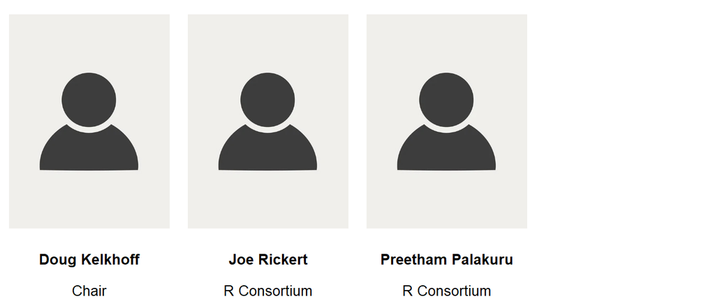

### Communications Workstream

The **Communications Workstream** focuses on how we build connections across the R world, specifically with our neighboring initiatives: the R Consortium, PhUSE, PSI AIMS, the R Submissions Working Group, and ROpenSci. This working group also supports the effort to make the R Validation Hub more intentional with how we organize ourselves and look into best means to disseminate information.

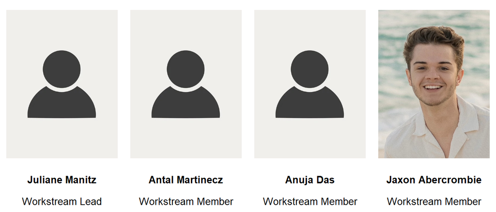

### Repositories Workstream

The **Repositories Workstream** supports a transparent, cross-industry approach of establishing and maintaining a repository of validated R packages.

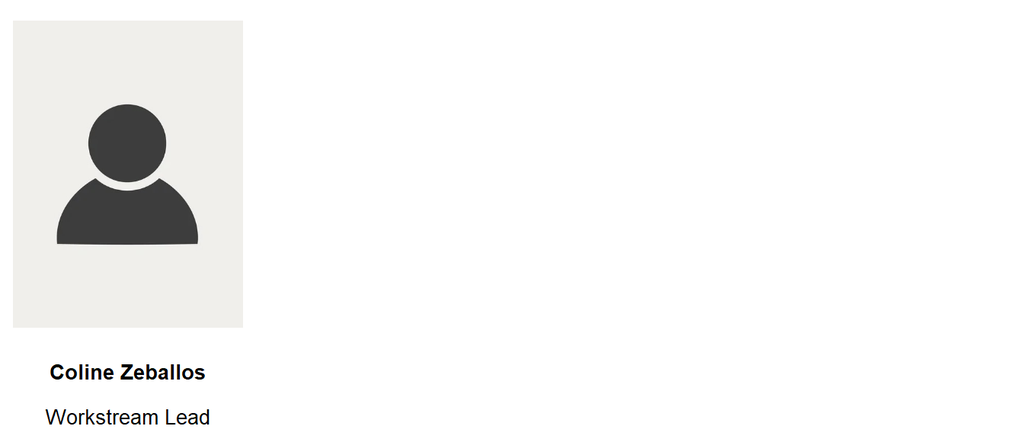

### {riskassessment} Application Workstream

The **{riskassessment} Workstream** leads the development of the risk assessment Shiny app (an extension of the {riskmetric} package) that provides a graphical interface to the package’s functionality.

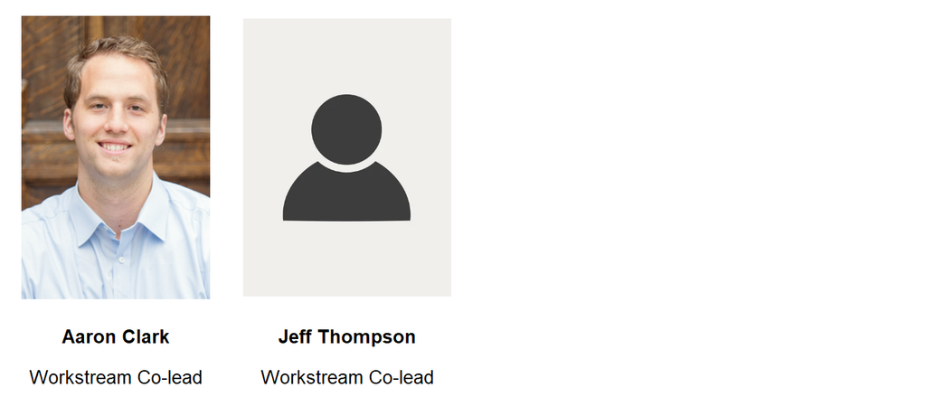

### {riskmetric} Workstream

The **{riskmetric} Workstream** leads the development of the {riskmetric} package that supports the idea of risk-based evaluation of R packages.

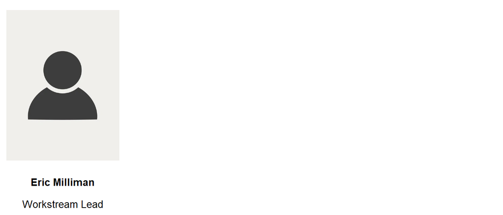

### Previous Members

*Andy Nicholls* (Chair 2018-2022)

*Lyn Taylor*, *Paulo Bargo*, *Marly Gotti*, *Yilong Zhang*, *Keaven Anderson*, *Min Lee*, *Parker Sims*